# Twitter Listener

### By Liam Smith

```python
from twython import Twython
from twython import TwythonStreamer
import codecs
import json
import time
import csv
import pandas as pd
import numpy as np
import seaborn as sns
import matplotlib.pyplot as plt

import text2emotion as te
import vaderSentiment
from vaderSentiment.vaderSentiment import SentimentIntensityAnalyzer

APIKEY='2oOfeGCZbERT9D5l8w0XAe4Xz'
APISecret='pswyV1HeKpue5gIKpc1hWs7kOeWQkwX7aFkKeKqvid4RBEbdUA'
AccessToken='1380516922186416130-tDv8bTxQArkbDsAroFhLP32IjACxkC'
AccessSecret='Yt5KC6Gm4bWwPRWI4xYoXfNEjfWoqedu3Tx0dJs1MYPQu'


twitter = Twython(APIKEY,APISecret,AccessToken,AccessSecret)
```

## Finding Tweets

The tweets collected were meant to all have to do with the new spiderman movie, specifically my goal was to see if the rumured actors were more tweeeted about and what sort of sentiment was contained in these tweets

```python
## This was moved to seperate notebook
```

### Dataframe

The next few blocks are taking the csv with in which the the tweets were compiled and creating a workable data frame.

```python
input_file = 'C:/Users/student/Documents/Junior/Fall/Programming/Twitter Project/ListenterRound5.csv'

data = pd.read_csv(input_file, header = None)
df = pd.DataFrame(data)
```

```python
print(df.head())
print(df.tail())
```

```
                       0         1                               2   \
0                      []  1.47E+18  Wed Dec 15 17:11:46 +0000 2021
1  ['SpiderManNoWayHome']  1.47E+18  Wed Dec 15 17:11:46 +0000 2021
2                      []  1.47E+18  Wed Dec 15 17:11:46 +0000 2021
3                      []  1.47E+18  Wed Dec 15 17:11:48 +0000 2021
4                      []  1.47E+18  Wed Dec 15 17:11:48 +0000 2021

                                                  3   \
0  @gee_shenka I was disappointed when I didn't s...
1  RT @thonystrank: I’m dying! Can you hear me? E...
2  RT @mm_cons: She also brought the guy that pla...
3                                      The art tho😲😲
4  RT @wrkhs: the making of zendaya’s spiderman d...

                                           4                5          6   \
```

[output cut: 53 more lines]

```python
df.shape

# Let's clean some things up. First let's give ourselves some valid column labels
df.columns = ['hashtags','tweet_id','created_at','text','name','user','user_id', 'user_loc', 'user_desc','user_followers',
              'user_friends','user_listed', 'user_created', 'user_favs','user_verified', 'user_statuses']

# Now let's change the setting so a print will show all of the columns, change the column max width so we can see the whole
# tweet, and show up to 100 rows
pd.set_option('display.max_columns', None) # This will make it so all columns appear when printing
pd.options.display.max_colwidth = 300  # This makes it so we can see the entire tweet text.
pd.set_option('display.max_rows', 100)

print(df)
```

```
                      hashtags  tweet_id                      created_at  \
0                           []  1.47E+18  Wed Dec 15 17:11:46 +0000 2021
1       ['SpiderManNoWayHome']  1.47E+18  Wed Dec 15 17:11:46 +0000 2021
2                           []  1.47E+18  Wed Dec 15 17:11:46 +0000 2021
3                           []  1.47E+18  Wed Dec 15 17:11:48 +0000 2021
4                           []  1.47E+18  Wed Dec 15 17:11:48 +0000 2021
...                        ...       ...                             ...
38797  ['SpiderManNowWayHome']  1.47e+18  Thu Dec 16 00:51:11 +0000 2021
38798                       []  1.47e+18  Thu Dec 16 00:51:12 +0000 2021
38799                       []  1.47e+18  Thu Dec 16 00:51:12 +0000 2021
38800                       []  1.47e+18  Thu Dec 16 00:51:12 +0000 2021
38801                       []  1.47e+18  Thu Dec 16 00:51:12 +0000 2021

                                                                                                                                          text  \
0                                                                        @gee_shenka I was disappointed when I didn't see you in one of these😂
```

[output cut: 77 more lines]

## Start of Sentiment Analysis

The following code grades the text column of tweets based on sentiment of the words used. It grades on a scale of -1 to 1 indicating how prevelant an emotion is in each tweet.

```python
sentiment = []
analyzer = SentimentIntensityAnalyzer()

for index, row in df.iterrows():
    tweet = str(row['text'])
    vs = analyzer.polarity_scores(tweet)
    sentiment.append(vs)

df['VaderSentiment'] = sentiment

df[['text','VaderSentiment']].head()
```

|  | text | VaderSentiment |
| --- | --- | --- |
| 0 | @gee_shenka I was disappointed when I didn't see you in one of these😂 | {'neg': 0.21, 'neu': 0.63, 'pos': 0.16, 'compound': -0.0516} |
| 1 | RT @thonystrank: I’m dying! Can you hear me? Emotional Peter aka The Amazing Spiderman causes of it #SpiderManNoWayHome ://t.co/licE6… | {'neg': 0.0, 'neu': 0.749, 'pos': 0.251, 'compound': 0.69} |
| 2 | RT @mm_cons: She also brought the guy that plays spiderman in the movies as an accessorie!! | {'neg': 0.0, 'neu': 0.853, 'pos': 0.147, 'compound': 0.3786} |
| 3 | The art tho😲😲 | {'neg': 0.0, 'neu': 0.49, 'pos': 0.51, 'compound': 0.6369} |
| 4 | RT @wrkhs: the making of zendaya’s spiderman dress by valentino ://t.co/Vqnvp7pfNo | {'neg': 0.0, 'neu': 1.0, 'pos': 0.0, 'compound': 0.0} |

```python
compound = []
for index, row in df.iterrows():
   # compund.append(row['VaderSentiment']['compound'])
   compound.append(row['VaderSentiment']['compound'])

df['VCompound'] = compound

df[['text','VaderSentiment', 'VCompound']].head()
```

|  | text | VaderSentiment | VCompound |
| --- | --- | --- | --- |
| 0 | @gee_shenka I was disappointed when I didn't see you in one of these😂 | {'neg': 0.21, 'neu': 0.63, 'pos': 0.16, 'compound': -0.0516} | -0.0516 |
| 1 | RT @thonystrank: I’m dying! Can you hear me? Emotional Peter aka The Amazing Spiderman causes of it #SpiderManNoWayHome ://t.co/licE6… | {'neg': 0.0, 'neu': 0.749, 'pos': 0.251, 'compound': 0.69} | 0.6900 |
| 2 | RT @mm_cons: She also brought the guy that plays spiderman in the movies as an accessorie!! | {'neg': 0.0, 'neu': 0.853, 'pos': 0.147, 'compound': 0.3786} | 0.3786 |
| 3 | The art tho😲😲 | {'neg': 0.0, 'neu': 0.49, 'pos': 0.51, 'compound': 0.6369} | 0.6369 |
| 4 | RT @wrkhs: the making of zendaya’s spiderman dress by valentino ://t.co/Vqnvp7pfNo | {'neg': 0.0, 'neu': 1.0, 'pos': 0.0, 'compound': 0.0} | 0.0000 |

```python
df[['VCompound']].agg(['count','mean','std'])
```

|  | VCompound |
| --- | --- |
| count | 38802.000000 |
| mean | 0.012966 |
| std | 0.282572 |

### Mentions

The following block has the task of determining if the names of the 3 spiderman are mentioned in tweets, or if a tweet mentions all 3. This will be able to tell us who is being talked about most, the rumured spiderman or the main star. It will also allow us to track sentiment on the mentioning of the three actors.

```python
def words_in_string(word_list, a_string):
    return set(word_list).intersection(a_string.split())

mention = []
tom = []
tobey = []
andrew = []
all3 = []

for index, row in df.iterrows():
    tweet = str(row['text'].lower())

    my_word_list = ['Tom', 'Holland', 'Homecoming','Far from home']
    if words_in_string(my_word_list, tweet):
        tom.append(1)
    else:
        tom.append(0)

    my_word_list = ['tobey', 'mqguire', 'raimi']

    if words_in_string(my_word_list, tweet):
        tobey.append(1)
    else:
        tobey.append(0)

    my_word_list = ['andrew', 'garfield', 'amazing']

    if words_in_string(my_word_list, tweet):
        andrew.append(1)
    else:
        andrew.append(0)


    if "tom" in tweet and "tobey" in tweet and "andrew" in tweet:
        all3.append(1)
    else:
        all3.append(0)

    if "tom" in tweet and "tobey" in tweet and "andrew" in tweet:
        mention.append('All 3')
    elif "tom" in tweet or 'holland' in tweet:
        mention.append('tom')
    elif "tobey" in tweet or'maguire' in tweet or 'raimi' in tweet:
        mention.append('tobey')
    elif "andrew" in tweet or 'garfield' in tweet or 'amazing' in tweet:
        mention.append('andrew')
    else:
        mention.append('None')


df['Tom'] = tom
df['Tobey'] = tobey
df['Andrew']= andrew
df['All 3'] = all3
df['Mentioned'] = mention
```

```python
df.head()
```

|  | hashtags | tweet_id | created_at | text | name | user | user_id | user_loc | user_desc | user_followers | user_friends | user_listed | user_created | user_favs | user_verified | user_statuses | VaderSentiment | VCompound | Tom | Tobey | Andrew | All 3 | Mentioned |
| --- | --- | --- | --- | --- | --- | --- | --- | --- | --- | --- | --- | --- | --- | --- | --- | --- | --- | --- | --- | --- | --- | --- | --- |
| 0 | [] | 1.47E+18 | Wed Dec 15 17:11:46 +0000 2021 | @gee_shenka I was disappointed when I didn't see you in one of these😂 | 𝓜𝓾𝓱𝓪𝓶𝓶𝓪𝓭 | __MuhdAdam | 1.03E+18 | The Batcave | Good genes 🧬 | 3597 | 1891 | 0 | Fri Aug 10 00:47:23 +0000 2018 | 133530 | FALSE | 75478.0 | {'neg': 0.21, 'neu': 0.63, 'pos': 0.16, 'compound': -0.0516} | -0.0516 | 0 | 0 | 0 | 0 | None |
| 1 | ['SpiderManNoWayHome'] | 1.47E+18 | Wed Dec 15 17:11:46 +0000 2021 | RT @thonystrank: I’m dying! Can you hear me? Emotional Peter aka The Amazing Spiderman causes of it #SpiderManNoWayHome ://t.co/licE6… | aku | rgnaptr | 309055813 | Indonesia | NaN | 653 | 482 | 1 | Wed Jun 01 13:17:03 +0000 2011 | 511 | FALSE | 46498.0 | {'neg': 0.0, 'neu': 0.749, 'pos': 0.251, 'compound': 0.69} | 0.6900 | 0 | 0 | 1 | 0 | andrew |
| 2 | [] | 1.47E+18 | Wed Dec 15 17:11:46 +0000 2021 | RT @mm_cons: She also brought the guy that plays spiderman in the movies as an accessorie!! | Mauricio ⭐️💧 | MAURICIOM0NTANA | 604644763 | DC | u either kill urself or get killed | 619 | 223 | 13 | Sun Jun 10 16:25:18 +0000 2012 | 8299 | FALSE | 276313.0 | {'neg': 0.0, 'neu': 0.853, 'pos': 0.147, 'compound': 0.3786} | 0.3786 | 0 | 0 | 0 | 0 | None |
| 3 | [] | 1.47E+18 | Wed Dec 15 17:11:48 +0000 2021 | The art tho😲😲 | Tofu Satsu | bobotmaksimum_ | 96916195 | NaN | bio ini kosong karena acap kali dibahas dalam perbincangan | 314 | 326 | 2 | Tue Dec 15 04:56:36 +0000 2009 | 359 | FALSE | 26602.0 | {'neg': 0.0, 'neu': 0.49, 'pos': 0.51, 'compound': 0.6369} | 0.6369 | 0 | 0 | 0 | 0 | None |
| 4 | [] | 1.47E+18 | Wed Dec 15 17:11:48 +0000 2021 | RT @wrkhs: the making of zendaya’s spiderman dress by valentino ://t.co/Vqnvp7pfNo | เป็นไอโอบ๊วยบ๊วย อวยบ๊วยจนกว่าชีวิตจะหาไม่ | Rrrrr0A0 | 8.37E+17 | NaN | ขอให้พระองค์เจ้าหญิงบ๊วยบ๊วยจงทรงพระเจริญยิ่งยืนนาน 🧡🖤🤍 | 14 | 337 | 0 | Thu Mar 02 13:50:10 +0000 2017 | 879 | FALSE | 8832.0 | {'neg': 0.0, 'neu': 1.0, 'pos': 0.0, 'compound': 0.0} | 0.0000 | 0 | 0 | 0 | 0 | None |

```python
df.groupby('Mentioned')['VCompound'].agg(['count','mean','std'])
```

| Mentioned | count | mean | std |
| --- | --- | --- | --- |
| All 3 | 103 | 0.114514 | 0.552053 |
| None | 36110 | 0.008305 | 0.268167 |
| andrew | 391 | 0.221706 | 0.450890 |
| tobey | 348 | 0.069622 | 0.385462 |
| tom | 1850 | 0.043517 | 0.414556 |

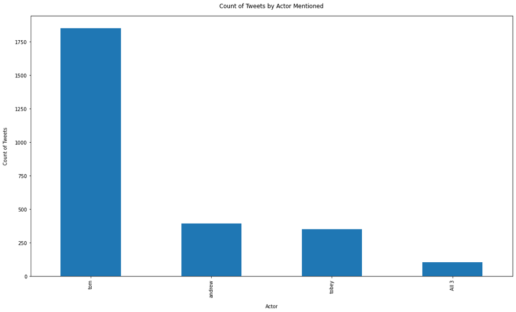

```python
data4=df
data5=data4[(data4.Mentioned != "None")]
data5['Mentioned'].value_counts()[:20].plot(figsize=(18,10),kind='bar')
plt.xlabel("Actor", labelpad=14)
plt.ylabel("Count of Tweets", labelpad=14)
plt.title("Count of Tweets by Actor Mentioned", y=1.02);
```

### Violin plot showing VCompound plotted by Actor mentioned

[figure not shown]

```python
ax = sns.violinplot(x=mention, y=compound, hue=USA,split=True)
ax.set_title("Compound score by Actor mentioned US or not")
ax.set_ylabel("Compound Vader Sentiment Score")
ax.set_xlabel("Actor Mentioned")
sns.set(rc = {'figure.figsize':(15,10)})
plt.show()
```

### The next blocks focus on the creation of the tweet time and emotion variables

The tweet time variable converts the previous time variable to something more easily understood The emotion variable finds the emotion of a tweet based on on its the text of the tweet. Because text2emotion was taking to long for the purposes of my data set I instead used a similiar module called nrclex, which completed in minutes.

```python
# Convert the Twitter Date/Time to a standard datetime.
import time
tweettime = []

for index, row in df.iterrows():
    try:
        ts = time.strftime('%Y-%m-%d %H:%M:%S', time.strptime(row['created_at'],'%a %b %d %H:%M:%S +0000 %Y'))
    except:
        ts = ''
    tweettime.append(ts)


df['Tweet time'] = tweettime
```

```python
df['Tweet time'] = pd.to_datetime(df['Tweet time'])
```

```python
from nrclex import NRCLex
```

```python
emotion=[]
for index, row in df.iterrows():
    tweet=str(row['text'])
    em=NRCLex(tweet)
    emotion.append(em.affect_frequencies)
df['Emotion']=emotion
```

```python
df.head()
```

|  | hashtags | tweet_id | created_at | text | name | user | user_id | user_loc | user_desc | user_followers | user_friends | user_listed | user_created | user_favs | user_verified | user_statuses | VaderSentiment | VCompound | Tom | Tobey | Andrew | All 3 | Mentioned | Tweet time | Emotion |
| --- | --- | --- | --- | --- | --- | --- | --- | --- | --- | --- | --- | --- | --- | --- | --- | --- | --- | --- | --- | --- | --- | --- | --- | --- | --- |
| 0 | [] | 1.47E+18 | Wed Dec 15 17:11:46 +0000 2021 | @gee_shenka I was disappointed when I didn't see you in one of these😂 | 𝓜𝓾𝓱𝓪𝓶𝓶𝓪𝓭 | __MuhdAdam | 1.03E+18 | The Batcave | Good genes 🧬 | 3597 | 1891 | 0 | Fri Aug 10 00:47:23 +0000 2018 | 133530 | FALSE | 75478.0 | {'neg': 0.21, 'neu': 0.63, 'pos': 0.16, 'compound': -0.0516} | -0.0516 | 0 | 0 | 0 | 0 | None | 2021-12-15 17:11:46 | {'fear': 0.0, 'anger': 0.25, 'anticip': 0.0, 'trust': 0.0, 'surprise': 0.0, 'positive': 0.0, 'negative': 0.25, 'sadness': 0.25, 'disgust': 0.25, 'joy': 0.0} |
| 1 | ['SpiderManNoWayHome'] | 1.47E+18 | Wed Dec 15 17:11:46 +0000 2021 | RT @thonystrank: I’m dying! Can you hear me? Emotional Peter aka The Amazing Spiderman causes of it #SpiderManNoWayHome ://t.co/licE6… | aku | rgnaptr | 309055813 | Indonesia | NaN | 653 | 482 | 1 | Wed Jun 01 13:17:03 +0000 2011 | 511 | FALSE | 46498.0 | {'neg': 0.0, 'neu': 0.749, 'pos': 0.251, 'compound': 0.69} | 0.6900 | 0 | 0 | 1 | 0 | andrew | 2021-12-15 17:11:46 | {'fear': 0.2, 'anger': 0.2, 'anticip': 0.0, 'trust': 0.0, 'surprise': 0.0, 'positive': 0.0, 'negative': 0.2, 'sadness': 0.2, 'disgust': 0.2, 'joy': 0.0} |
| 2 | [] | 1.47E+18 | Wed Dec 15 17:11:46 +0000 2021 | RT @mm_cons: She also brought the guy that plays spiderman in the movies as an accessorie!! | Mauricio ⭐️💧 | MAURICIOM0NTANA | 604644763 | DC | u either kill urself or get killed | 619 | 223 | 13 | Sun Jun 10 16:25:18 +0000 2012 | 8299 | FALSE | 276313.0 | {'neg': 0.0, 'neu': 0.853, 'pos': 0.147, 'compound': 0.3786} | 0.3786 | 0 | 0 | 0 | 0 | None | 2021-12-15 17:11:46 | {'fear': 0.0, 'anger': 0.0, 'anticip': 0.0, 'trust': 0.0, 'surprise': 0.0, 'positive': 0.0, 'negative': 0.0, 'sadness': 0.0, 'disgust': 0.0, 'joy': 0.0} |
| 3 | [] | 1.47E+18 | Wed Dec 15 17:11:48 +0000 2021 | The art tho😲😲 | Tofu Satsu | bobotmaksimum_ | 96916195 | NaN | bio ini kosong karena acap kali dibahas dalam perbincangan | 314 | 326 | 2 | Tue Dec 15 04:56:36 +0000 2009 | 359 | FALSE | 26602.0 | {'neg': 0.0, 'neu': 0.49, 'pos': 0.51, 'compound': 0.6369} | 0.6369 | 0 | 0 | 0 | 0 | None | 2021-12-15 17:11:48 | {'fear': 0.0, 'anger': 0.0, 'anticip': 0.0, 'trust': 0.0, 'surprise': 0.2, 'positive': 0.2, 'negative': 0.0, 'sadness': 0.2, 'disgust': 0.0, 'joy': 0.2, 'anticipation': 0.2} |
| 4 | [] | 1.47E+18 | Wed Dec 15 17:11:48 +0000 2021 | RT @wrkhs: the making of zendaya’s spiderman dress by valentino ://t.co/Vqnvp7pfNo | เป็นไอโอบ๊วยบ๊วย อวยบ๊วยจนกว่าชีวิตจะหาไม่ | Rrrrr0A0 | 8.37E+17 | NaN | ขอให้พระองค์เจ้าหญิงบ๊วยบ๊วยจงทรงพระเจริญยิ่งยืนนาน 🧡🖤🤍 | 14 | 337 | 0 | Thu Mar 02 13:50:10 +0000 2017 | 879 | FALSE | 8832.0 | {'neg': 0.0, 'neu': 1.0, 'pos': 0.0, 'compound': 0.0} | 0.0000 | 0 | 0 | 0 | 0 | None | 2021-12-15 17:11:48 | {'fear': 0.0, 'anger': 0.0, 'anticip': 0.0, 'trust': 0.0, 'surprise': 0.0, 'positive': 0.0, 'negative': 0.0, 'sadness': 0.0, 'disgust': 0.0, 'joy': 0.0} |

### The next blocks create filtered data frames for use in the visualizations of mentioned by count and region by count

```python
data2=df
data2= data[(data.Region != "Other")]
data2.head()
```

[output not shown]

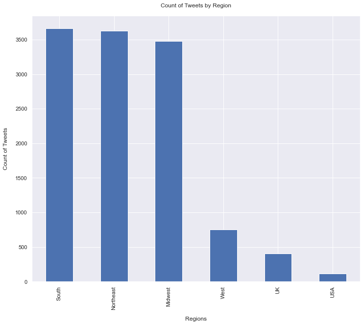

```python
data2['Region'].value_counts()[:20].plot(figsize=(12,10),kind='bar')
plt.xlabel("Regions", labelpad=14)
plt.ylabel("Count of Tweets", labelpad=14)
plt.title("Count of Tweets by Region", y=1.02);
```

```python
data4=df
data5= data4[(data4.Mentioned != "Niether")]
data5.head()
```

|  | hashtags | tweet_id | created_at | text | name | user | user_id | user_loc | user_desc | user_followers | user_friends | user_listed | user_created | user_favs | user_verified | user_statuses | VaderSentiment | VCompound | Tom | Tobey | Andrew | All 3 | Mentioned | Tweet time | Emotion | USA | AZ | UT | TX | … |
| --- | --- | --- | --- | --- | --- | --- | --- | --- | --- | --- | --- | --- | --- | --- | --- | --- | --- | --- | --- | --- | --- | --- | --- | --- | --- | --- | --- | --- | --- | --- |
| 0 | [] | 1.47E+18 | Wed Dec 15 17:11:46 +0000 2021 | @gee_shenka I was disappointed when I didn't see you in one of these😂 | 𝓜𝓾𝓱𝓪𝓶𝓶𝓪𝓭 | __MuhdAdam | 1.03E+18 | The Batcave | Good genes 🧬 | 3597 | 1891 | 0 | Fri Aug 10 00:47:23 +0000 2018 | 133530 | FALSE | 75478.0 | {'neg': 0.21, 'neu': 0.63, 'pos': 0.16, 'compound': -0.0516} | -0.0516 | 0 | 0 | 0 | 0 | None | 2021-12-15 17:11:46 | {'fear': 0.0, 'anger': 0.25, 'anticip': 0.0, 'trust': 0.0, 'surprise': 0.0, 'positive': 0.0, 'negative': 0.25, 'sadness': 0.25, 'disgust': 0.25, 'joy': 0.0} | 0 | 0 | 0 | 0 | … |
| 1 | ['SpiderManNoWayHome'] | 1.47E+18 | Wed Dec 15 17:11:46 +0000 2021 | RT @thonystrank: I’m dying! Can you hear me? Emotional Peter aka The Amazing Spiderman causes of it #SpiderManNoWayHome ://t.co/licE6… | aku | rgnaptr | 309055813 | Indonesia | NaN | 653 | 482 | 1 | Wed Jun 01 13:17:03 +0000 2011 | 511 | FALSE | 46498.0 | {'neg': 0.0, 'neu': 0.749, 'pos': 0.251, 'compound': 0.69} | 0.6900 | 0 | 0 | 1 | 0 | andrew | 2021-12-15 17:11:46 | {'fear': 0.2, 'anger': 0.2, 'anticip': 0.0, 'trust': 0.0, 'surprise': 0.0, 'positive': 0.0, 'negative': 0.2, 'sadness': 0.2, 'disgust': 0.2, 'joy': 0.0} | 0 | 0 | 0 | 0 | … |
| 2 | [] | 1.47E+18 | Wed Dec 15 17:11:46 +0000 2021 | RT @mm_cons: She also brought the guy that plays spiderman in the movies as an accessorie!! | Mauricio ⭐️💧 | MAURICIOM0NTANA | 604644763 | DC | u either kill urself or get killed | 619 | 223 | 13 | Sun Jun 10 16:25:18 +0000 2012 | 8299 | FALSE | 276313.0 | {'neg': 0.0, 'neu': 0.853, 'pos': 0.147, 'compound': 0.3786} | 0.3786 | 0 | 0 | 0 | 0 | None | 2021-12-15 17:11:46 | {'fear': 0.0, 'anger': 0.0, 'anticip': 0.0, 'trust': 0.0, 'surprise': 0.0, 'positive': 0.0, 'negative': 0.0, 'sadness': 0.0, 'disgust': 0.0, 'joy': 0.0} | 0 | 0 | 0 | 0 | … |
| 3 | [] | 1.47E+18 | Wed Dec 15 17:11:48 +0000 2021 | The art tho😲😲 | Tofu Satsu | bobotmaksimum_ | 96916195 | NaN | bio ini kosong karena acap kali dibahas dalam perbincangan | 314 | 326 | 2 | Tue Dec 15 04:56:36 +0000 2009 | 359 | FALSE | 26602.0 | {'neg': 0.0, 'neu': 0.49, 'pos': 0.51, 'compound': 0.6369} | 0.6369 | 0 | 0 | 0 | 0 | None | 2021-12-15 17:11:48 | {'fear': 0.0, 'anger': 0.0, 'anticip': 0.0, 'trust': 0.0, 'surprise': 0.2, 'positive': 0.2, 'negative': 0.0, 'sadness': 0.2, 'disgust': 0.0, 'joy': 0.2, 'anticipation': 0.2} | 0 | 0 | 0 | 0 | … |
| 4 | [] | 1.47E+18 | Wed Dec 15 17:11:48 +0000 2021 | RT @wrkhs: the making of zendaya’s spiderman dress by valentino ://t.co/Vqnvp7pfNo | เป็นไอโอบ๊วยบ๊วย อวยบ๊วยจนกว่าชีวิตจะหาไม่ | Rrrrr0A0 | 8.37E+17 | NaN | ขอให้พระองค์เจ้าหญิงบ๊วยบ๊วยจงทรงพระเจริญยิ่งยืนนาน 🧡🖤🤍 | 14 | 337 | 0 | Thu Mar 02 13:50:10 +0000 2017 | 879 | FALSE | 8832.0 | {'neg': 0.0, 'neu': 1.0, 'pos': 0.0, 'compound': 0.0} | 0.0000 | 0 | 0 | 0 | 0 | None | 2021-12-15 17:11:48 | {'fear': 0.0, 'anger': 0.0, 'anticip': 0.0, 'trust': 0.0, 'surprise': 0.0, 'positive': 0.0, 'negative': 0.0, 'sadness': 0.0, 'disgust': 0.0, 'joy': 0.0} | 0 | 0 | 0 | 0 | … |

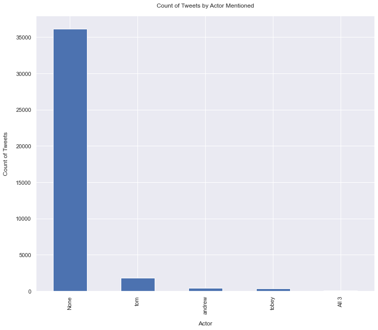

```python
data5['Mentioned'].value_counts()[:20].plot(figsize=(12,10),kind='bar')
plt.xlabel("Actor", labelpad=14)
plt.ylabel("Count of Tweets", labelpad=14)
plt.title("Count of Tweets by Actor Mentioned", y=1.02);
```

## Location

The next lines of code take the location provided by the base tweet and determine whether or not the location is in the united states, creating a USA variable with values of true or false

```python
df['user_loc'].groupby(df['user_loc']).value_counts().nlargest(20)
```

```
user_loc                                                                                                                                         user_loc
she/her                                                                                                                                          she/her                                                                                                                                            191
Malibu, CA                                                                                                                                       Malibu, CA                                                                                                                                         175
22                                                                                                                                               22                                                                                                                                                 150
London, England                                                                                                                                  London, England                                                                                                                                    115
London                                                                                                                                           London                                                                                                                                              72
England, United Kingdom                                                                                                                          England, United Kingdom                                                                                                                             51
Los Angeles, CA                                                                                                                                  Los Angeles, CA                                                                                                                                     44
Reader. Unapologetic student. Web lover. Passionate explorer. Gamer. Coffee aficionado. Subtly charming problem solver.                          Reader. Unapologetic student. Web lover. Passionate explorer. Gamer. Coffee aficionado. Subtly charming problem solver.                             44
Malaysia                                                                                                                                         Malaysia                                                                                                                                            43
Amateur twitter aficionado. Internet evangelist. Coffee specialist. Food practitioner. Devoted tvaholic.                                         Amateur twitter aficionado. Internet evangelist. Coffee specialist. Food practitioner. Devoted tvaholic.                                            42
Certified coffee specialist. Infuriatingly humble zombie trailblazer. Tv expert. Reader. Thinker. Alcohol buff. Web aficionado. Problem solver.  Certified coffee specialist. Infuriatingly humble zombie trailblazer. Tv expert. Reader. Thinker. Alcohol buff. Web aficionado. Problem solver.     42
Pop culture ninja. General bacon junkie. Proud web maven. Amateur internet expert. Hardcore twitter fan.                                         Pop culture ninja. General bacon junkie. Proud web maven. Amateur internet expert. Hardcore twitter fan.                                            42
Communicator. Entrepreneur. Friendly web geek. Tv ninja. Social media trailblazer. Travel fanatic.                                               Communicator. Entrepreneur. Friendly web geek. Tv ninja. Social media trailblazer. Travel fanatic.                                                  41
```

[output cut: 8 more lines]

```python
usa = []
state_list = ["alaska", "alabama", "arkansas", "american samoa", "arizona", "california", "colorado", "connecticut", "district of columbia", "delaware", "florida", "georgia", "guam", "hawaii", "iowa", "idaho", "illinois", "indiana", "kansas", "kentucky", "louisiana", "massachusetts", "maryland", "maine", "michigan", "minnesota", "missouri", "mississippi", "montana", "north carolina", "north dakota", "nebraska", "new hampshire", "new jersey", "new mexico", "nevada", "new york", "ohio", "oklahoma", "oregon", "pennsylvania", "puerto rico", "rhode island", "south carolina", "south dakota", "tennessee", "texas", "utah", "virginia", "virgin islands", "vermont", "washington", "wisconsin", "west virginia", "wyoming"]
country_list = ['usa', 'united states']


for index, row in df.iterrows():
    location = str(row['user_loc']).lower()
    location = location.replace(",", "")

    if any(map(location.__contains__, country_list)):
        usa.append(True)
    elif any(map(location.__contains__, state_list)):
        usa.append(True)
    else:
        usa.append(False)

df['USA'] = usa
```

```python
df['USA'].groupby(df['user_loc']).value_counts().nlargest(20)
```

```
user_loc                                                                                                                                         USA
she/her                                                                                                                                          False    191
Malibu, CA                                                                                                                                       False    175
22                                                                                                                                               False    150
London, England                                                                                                                                  False    115
London                                                                                                                                           False     72
England, United Kingdom                                                                                                                          False     51
Los Angeles, CA                                                                                                                                  False     44
Reader. Unapologetic student. Web lover. Passionate explorer. Gamer. Coffee aficionado. Subtly charming problem solver.                          False     44
Malaysia                                                                                                                                         False     43
Amateur twitter aficionado. Internet evangelist. Coffee specialist. Food practitioner. Devoted tvaholic.                                         False     42
Certified coffee specialist. Infuriatingly humble zombie trailblazer. Tv expert. Reader. Thinker. Alcohol buff. Web aficionado. Problem solver.  False     42
Pop culture ninja. General bacon junkie. Proud web maven. Amateur internet expert. Hardcore twitter fan.                                         False     42
Communicator. Entrepreneur. Friendly web geek. Tv ninja. Social media trailblazer. Travel fanatic.                                               False     41
Entrepreneur. Music fan. Bacon fanatic. Tv maven. Wannabe food evangelist. Devoted beer junkie.                                                  False     41
United Kingdom                                                                                                                                   False     39
Indonesia                                                                                                                                        False     34
United States                                                                                                                                    True      32
California, USA                                                                                                                                  True      31
Houston, TX                                                                                                                                      False     29
.                                                                                                                                                False     28
Name: USA, dtype: int64
```

### State and Region

The next two blocks gave me the biggest amount of struggle throughout this project. The given code for creating variables based on the states was easy enough and ran without any interferance, but I felt that any sort of visualization based on the location variables would be rather silly when dealing with all 50 states, the UK, and the US. So I felt that it was necessarry to create the variable of Region, grouping the states by Northeast, West, South, Midwest, UK and USA (for all others in the US).

```python
TX=[]
GA=[]
IL=[]
MA=[]
PA=[]
CA=[]
WA=[]
ME=[]
NH=[]
VT=[]
NY=[]
CT=[]
RI=[]
NJ=[]
DE=[]
MD=[]
DC=[]
VA=[]
WV=[]
NC=[]
SC=[]
FL=[]
AL=[]
TN=[]
KY=[]
OH=[]
MI=[]
USA=[]
IN=[]
WI=[]
MS=[]
LA=[]
AR=[]
MO=[]
IA=[]
MT=[]
MN=[]
ND=[]
SD=[]
NE=[]
KS=[]
OK=[]
NM=[]
CO=[]
WY=[]
ID=[]
UT=[]
AZ=[]
NV=[]
OR=[]
HI=[]
AK=[]
UK=[]

Location=[]


for index, row in df.iterrows():
    tweet = str(row['user_loc'])

    if "Dallas" in tweet or "Houston" in tweet or "TX" in tweet or "Tx" in tweet or "tx" in tweet or "Austin" in tweet or "Texas" in tweet:
        TX.append(1)

    else:
        TX.append(0)
    if "Atlanta" in tweet or "GA" in tweet or "Georgia" in tweet or "Ga" in tweet or "ga" in tweet or "georgia" in tweet:
        GA.append(1)
    else:
        GA.append(0)
    if "Chicago" in tweet or "IL" in tweet or "Illinois" in tweet or "il" in tweet or "illinois" in tweet:
        IL.append(1)
    else:
        IL.append(0)
    if "Massachusetts" in tweet or "MA" in tweet or "ma" in tweet or "massachusetts" in tweet or "Boston" in tweet or "Worcester" in tweet or "Springfield" in tweet or "MA" in tweet:
        MA.append(1)
    else:
        MA.append (0)
    if "PA" in tweet or "Pennsylvania" in tweet or "Philidalphia" in tweet or "Philly" in tweet or "Pittsburgh" in tweet:
        PA.append(1)
    else:
        PA.append(0)
    if "CA" in tweet or "California" in tweet or "Los Angeles" in tweet or "Cali" in tweet or "San Bernardino" in tweet or "Orange" in tweet:
        CA.append(1)
    else:
        CA.append(0)
    if "WA" in tweet or "Seattle" in tweet or "Spokane" in tweet or "Washington" in tweet:
        WA.append(1)
    else:
        WA.append(0)
    if "ME" in tweet or "Maine" in tweet:
        ME.append(1)
    else:
        ME.append(0)
    if "NH" in tweet or "New Hampshire" in tweet or "Concord" in tweet:
        NH.append(1)
    else:
        NH.append(0)
    if "VT" in tweet or "Vermont" in tweet:
        VT.append(1)
    else:
        VT.append(0)
    if "NY" in tweet or "New York" in tweet or "Albany" in tweet or "Manhattan" in tweet or "Long Island" in tweet:
        NY.append(1)
    else:
        NY.append(0)
    if "CT" in tweet or "Connecticut" in tweet or "Hartford" in tweet or "Stanford" in tweet or "New London" in tweet or "New Haven" in tweet:
        CT.append(1)
    else:
        CT.append(0)
    if "RI" in tweet or "Rhode Island" in tweet or "Providence" in tweet or "Fall River" in tweet or "Pawtucket" in tweet:
        RI.append(1)
    else:
        RI.append(0)
    if "NJ" in tweet or "New Jersey" in tweet or "Jersey" in tweet or "Jersey Shore" in tweet:
        NJ.append(1)
    else:
        NJ.append(0)
    if "DE" in tweet or "Delaware" in tweet:
        DE.append(1)
    else:
        DE.append(0)
    if "MD" in tweet or "Ocean City" in tweet or "Baltimore" in tweet or "Maryland" in tweet:
        MD.append(1)
    else:
        MD.append(0)
    if "DC" in tweet or "District of Columbia" in tweet:
        DC.append(1)
    else:
        DC.append(0)
    if "VA" in tweet or "Virginia" in tweet or "Richmond" in tweet:
        VA.append(1)
    else:
        VA.append(0)
    if "WV" in tweet or "West Virginia" in tweet or "Charleston" in tweet:
        WV.append(1)
    else:
        WV.append(0)
    if "NC" in tweet or "North Carolina" in tweet or "Outter Banks" in tweet or "Raleigh" in tweet:
        NC.append(1)
    else:
        NC.append(0)
    if "SC" in tweet or "South Carolina" in tweet or "Columbia" in tweet:
        SC.append(1)
    else:
        SC.append(0)
    if "FL" in tweet or "Florida" in tweet or "Orlando" in tweet or "Sarasota" in tweet or "Daytona" in tweet or "Gainsville" in tweet or "Clearwater" in tweet or "Saint Petersburg" in tweet or "Tallahassee" in tweet:
        FL.append(1)
    else:
        FL.append(0)
    if "AL" in tweet or "Alabama" in tweet or "Birmingham" in tweet or "Bessemer" in tweet or "Montgomery" in tweet or "Mobile" in tweet:
        AL.append(1)
    else:
        AL.append(0)
    if "TN" in tweet or "Tennessee" in tweet or "Knoxville" in tweet or "Chattanooga" in tweet:
        TN.append(1)
    else:
        TN.append(0)
    if "KY" in tweet or "Kentucky" in tweet or "Lexington" in tweet or "Louisville" in tweet:
        KY.append(1)
    else:
        KY.append(0)
    if "OH" in tweet or "Ohio" in tweet or "Cincinnati" in tweet:
        OH.append(1)
    else:
        OH.append(0)
    if "MI" in tweet or "Michigan" in tweet or "Detroit" in tweet or "Novi" in tweet:
        MI.append(1)
    else:
        MI.append(0)
    if "USA" in tweet or "US" in tweet or "United States" in tweet or "America" in tweet or "United States of America" in tweet:
        USA.append(1)
    else:
        USA.append(0)
    if "IN" in tweet or "Indiana" in tweet or "Indy" in tweet or "Indianapolis" in tweet:
        IN.append(1)
    else:
        IN.append(0)
    if "WI" in tweet or "Wisconsin" in tweet:
        WI.append(1)
    else:
        WI.append(0)
    if "MS" in tweet or "Mississippi" in tweet or "Jackson" in tweet:
        MS.append(1)
    else:
        MS.append(0)
    if "LA" in tweet or "Louisiana" in tweet or "The Big Easy" in tweet or "New Orleans" in tweet:
        LA.append(1)
    else:
        LA.append(0)
    if "AR" in tweet or "Arkansas" in tweet or "Little Rock" in tweet:
        AR.append(1)
    else:
        AR.append(0)
    if "MO" in tweet or "Missouri" in tweet or "Saint Louis" in tweet or "Kansas City" in tweet:
        MO.append(1)
    else:
        MO.append(0)
    if "IA" in tweet or "Iowa" in tweet or "Des Moines" in tweet:
        IA.append(1)
    else:
        IA.append(0)
    if "MT" in tweet or "Montana" in tweet or "Helena" in tweet:
        MT.append(1)
    else:
        MT.append(0)
    if "MN" in tweet or "Minnesota" in tweet or "Saint Paul" in tweet:
        MN.append(1)
    else:
        MN.append(0)
    if "ND" in tweet or "North Dakota" in tweet or "Bismark" in tweet:
        ND.append(1)
    else:
        ND.append(0)
    if "SD" in tweet or "South Dakota" in tweet or "Pierre" in tweet:
        SD.append(1)
    else:
        SD.append(0)
    if "NE" in tweet or "Nebraska" in tweet or "Lincoln" in tweet:
        NE.append(1)
    else:
        NE.append(0)
    if "KS" in tweet or "Kansas" in tweet or "Topeka" in tweet:
        KS.append(1)
    else:
        KS.append(0)
    if "OK" in tweet or "Oklahoma" in tweet or "Oklahoma City" in tweet:
        OK.append(1)
    else:
        OK.append(0)
    if "NM" in tweet or "New Mexico" in tweet or "Albuquerque" in tweet:
        NM.append(1)
    else:
        NM.append(0)
    if "CO" in tweet or "Colorado" in tweet or "Denver" in tweet or "Colorado Springs" in tweet:
        CO.append(1)
    else:
        CO.append(0)
    if "WY" in tweet or "Wyoming" in tweet or "Cheyenne" in tweet:
        WY.append(1)
    else:
        WY.append(0)
    if "ID" in tweet or "Idaho" in tweet or "Boise" in tweet:
        ID.append(1)
    else:
        ID.append(0)
    if "UT" in tweet or "Utah" in tweet or "Salk Lake City" in tweet:
        UT.append(1)
    else:
        UT.append(0)
    if "AZ" in tweet or "Arizona" in tweet or "Phoenix" in tweet or "Pheonix" in tweet or "Scottsdale" in tweet:
        AZ.append(1)
    else:
        AZ.append(0)
    if "NV" in tweet or "Nevada" in tweet or "Las Vegas" in tweet or "Vegas" in tweet:
        NV.append(1)
    else:
        NV.append(0)
    if "OR" in tweet or "Oregon" in tweet or "Portland" in tweet:
        OR.append(1)
    else:
        OR.append(0)
    if "HI" in tweet or "Hawaii" in tweet or "Kapolei" in tweet or "Honolulu" in tweet:
        HI.append(1)
    else:
        HI.append(0)
    if "AK" in tweet or "Alaska" in tweet or "Juneau" in tweet or "Anchorage" in tweet:
        AK.append(1)
    else:
        AK.append(0)
    if "UK" in tweet or "United Kingdon" in tweet or "England" in tweet:
        UK.append(1)
    else:
        UK.append(0)
```

```python
    if "Dallas" in tweet or "Houston" in tweet or "TX" in tweet or "Tx" in tweet or "tx" in tweet or "Austin" in tweet or "Texas" in tweet:
        Location.append('TX')
    elif "Atlanta" in tweet or "GA" in tweet or "Georgia" in tweet or "Ga" in tweet or "ga" in tweet or "georgia" in tweet:
        Location.append('GA')
    elif "Chicago" in tweet or "IL" in tweet or "Illinois" in tweet or "il" in tweet or "illinois" in tweet:
        Location.append('IL')
    elif  "Massachusetts" in tweet or "MA" in tweet or "ma" in tweet or "massachusetts" in tweet or "Boston" in tweet or "Worcester" in tweet or "Springfield" in tweet or "MA" in tweet:
        Location.append('MA')
    elif "PA" in tweet or "Pennsylvania" in tweet or "Philidalphia" in tweet or "Philly" in tweet or "Pittsburgh" in tweet:
        Location.append ('PA')
    elif "CA" in tweet or "California" in tweet or "Los Angeles" in tweet or "Cali" in tweet or "San Bernardino" in tweet or "Orange" in tweet:
        Location.append('CA')
    elif "WA" in tweet or "Seattle" in tweet or "Spokane" in tweet or "Washington" in tweet:
        Location.append('WA')
    elif "ME" in tweet or "Maine" in tweet:
        Location.append('ME')
    elif "NH" in tweet or "New Hampshire" in tweet or "Concord" in tweet:
        Location.append('NH')
    elif "VT" in tweet or "Vermont" in tweet:
        Location.append('VT')
    elif "NY" in tweet or "New York" in tweet or "Albany" in tweet or "Manhattan" in tweet or "Long Island" in tweet:
        Location.append('NY')
    elif "CT" in tweet or "Connecticut" in tweet or "Hartford" in tweet or "Stanford" in tweet or "New London" in tweet or "New Haven" in tweet:
        Location.append('CT')
    elif "RI" in tweet or "Rhode Island" in tweet or "Providence" in tweet or "Fall River" in tweet or "Pawtucket" in tweet:
        Location.append('RI')
    elif "NJ" in tweet or "New Jersey" in tweet or "Jersey" in tweet or "Jersey Shore" in tweet:
        Location.append('NJ')
    elif "DE" in tweet or "Delaware" in tweet:
        Location.append('DE')
    elif "MD" in tweet or "Ocean City" in tweet or "Baltimore" in tweet or "Maryland" in tweet:
        Location.append('MD')
    elif "DC" in tweet or "District of Columbia" in tweet:
        Location.append('DC')
    elif "VA" in tweet or "Virginia" in tweet or "Richmond" in tweet:
        Location.append('VA')
    elif "WV" in tweet or "West Virginia" in tweet or "Charleston" in tweet:
        Location.append('WV')
    elif "NC" in tweet or "North Carolina" in tweet or "Outter Banks" in tweet or "Raleigh" in tweet:
        Location.append('NC')
    elif "SC" in tweet or "South Carolina" in tweet or "Columbia" in tweet:
        Location.append('SC')
    elif "FL" in tweet or "Florida" in tweet or "Orlando" in tweet or "Sarasota" in tweet or "Daytona" in tweet or "Gainsville" in tweet or "Clearwater" in tweet or "Saint Petersburg" in tweet or "Tallahassee" in tweet:
        Location.append('FL')
    elif "AL" in tweet or "Alabama" in tweet or "Birmingham" in tweet or "Bessemer" in tweet or "Montgomery" in tweet or "Mobile" in tweet:
        Location.append('AL')
    elif "TN" in tweet or "Tennessee" in tweet or "Knoxville" in tweet or "Chattanooga" in tweet:
        Location.append('TN')
    elif "KY" in tweet or "Kentucky" in tweet or "Lexington" in tweet or "Louisville" in tweet:
        Location.append('KY')
    elif "OH" in tweet or "Ohio" in tweet or "Cincinnati" in tweet:
        Location.append('OH')
    elif "MI" in tweet or "Michigan" in tweet or "Detroit" in tweet or "Novi" in tweet:
        Location.append("MI")
    elif "IN" in tweet or "Indiana" in tweet or "Indy" in tweet or "Indianapolis" in tweet:
        Location.append('IN')
    elif "WI" in tweet or "Wisconsin" in tweet:
        Location.append('WI')
    elif "MS" in tweet or "Mississippi" in tweet or "Jackson" in tweet:
        Location.append('MS')
    elif "LA" in tweet or "Louisiana" in tweet or "The Big Easy" in tweet or "New Orleans" in tweet:
        Location.append('LA')
    elif "AR" in tweet or "Arkansas" in tweet or "Little Rock" in tweet:
        Location.append('AR')
    elif "MO" in tweet or "Missouri" in tweet or "Saint Louis" in tweet or "Kansas City" in tweet:
        Location.append('MO')
    elif "IA" in tweet or "Iowa" in tweet or "Des Moines" in tweet:
        Location.append('IA')
    elif "MT" in tweet or "Montana" in tweet or "Helena" in tweet:
        Location.append('MT')
    elif "MN" in tweet or "Minnesota" in tweet or "Saint Paul" in tweet:
        Location.append('MN')
    elif "ND" in tweet or "North Dakota" in tweet or "Bismark" in tweet:
        Location.append('ND')
    elif "SD" in tweet or "South Dakota" in tweet or "Pierre" in tweet:
        Location.append('SD')
    elif "NE" in tweet or "Nebraska" in tweet or "Lincoln" in tweet:
        Location.append('NE')
    elif "KS" in tweet or "Kansas" in tweet or "Topeka" in tweet:
        Location.append('KS')
    elif "OK" in tweet or "Oklahoma" in tweet or "Oklahoma City" in tweet:
        Location.append('OK')
    elif "NM" in tweet or "New Mexico" in tweet or "Albuquerque" in tweet:
        Location.append('NM')
    elif "CO" in tweet or "Colorado" in tweet or "Denver" in tweet or "Colorado Springs" in tweet:
        Location.append('CO')
    elif "WY" in tweet or "Wyoming" in tweet or "Cheyenne" in tweet:
        Location.append('WY')
    elif "ID" in tweet or "Idaho" in tweet or "Boise" in tweet:
        Location.append('ID')
    elif "UT" in tweet or "Utah" in tweet or "Salk Lake City" in tweet:
        Location.append('UT')
    elif "AZ" in tweet or "Arizona" in tweet or "Phoenix" in tweet or "Pheonix" in tweet or "Scottsdale" in tweet:
        Location.append('AZ')
    elif "NV" in tweet or "Nevada" in tweet or "Las Vegas" in tweet or "Vegas" in tweet:\
        Location.append('NV')
    elif "OR" in tweet or "Oregon" in tweet or "Portland" in tweet:
        Location.append('OR')
    elif "HI" in tweet or "Hawaii" in tweet or "Kapolei" in tweet or "Honolulu" in tweet:
        Location.append('HI')
    elif "AK" in tweet or "Alaska" in tweet or "Juneau" in tweet or "Anchorage" in tweet:
        Location.append('AK')
    elif "UK" in tweet or "United Kingdon" in tweet or "England" in tweet:
        Location.append('UK')
```

```python
    elif "USA" in tweet or "US" in tweet or "United States" in tweet or "America" in tweet or "United States of America" in tweet:
        Location.append('USA')
    else:
        Location.append('Z_Unknown')


df['AZ']=AZ
df['UT']=UT
df['TX']=TX
df['OK']=OK
df['NE']=NE
df['GA']=GA
df['IL']=IL
df['MA']=MA
df['PA']=PA
df['CA']=CA
df['WA']=WA
df['ME']=ME
df['NH']=NH
df['VT']=VT
df['NY']=NY
df['CT']=CT
df['RI']=RI
df['NJ']=NJ
df['DE']=DE
df['MD']=MD
df['DC']=DC
df['VA']=VA
df['WV']=WV
df['NC']=NC
df['SC']=SC
df['FL']=FL
df['AL']=AL
df['TN']=TN
df['KY']=KY
df['OH']=OH
df['MI']=MI
df['USA']=USA
df['IN']=IN
df['WI']=WI
df['MS']=MS
df['LA']=LA
df['AR']=AR
df['MO']=MO
df['IA']=IA
df['MT']=MT
df['MN']=MN
df['ND']=ND
df['SD']=SD
df['KS']=KS
df['NM']=NM
df['CO']=CO
df['WY']=WY
df['ID']=ID
df['NV']=NV
df['OR']=OR
df['HI']=HI
df['AK']=AK
df['UK']=UK
df['Location']= Location
```

```python
Region=[]

for index, row in df.iterrows():
    Location = str(row['Location'])

    if 'RI'in Location or 'NY'in Location or 'ME'in Location or 'MA'in Location or 'PA'in Location or 'NH'in Location or 'VT'in Location or 'CT'in Location or 'NJ'in Location:
        Region.append("Northeast")
    elif 'TX'in Location or 'GA'in Location or 'DE'in Location or 'MD'in Location or'DC'in Location or 'VA'in Location or 'WV'in Location or 'NC'in Location or 'SC'in Location or 'FL'in Location or 'AL'in Location or 'TN'in Location or 'KY'in Location or 'MS'in Location or 'LA'in Location or 'AR'in Location or 'MO'in Location:
        Region.append('South')
    elif 'CA' in Location or 'WA' in Location or 'NM' in Location or 'CO' in Location or 'WY' in Location or 'ID' in Location or 'OR' in Location or 'AK' in Location or 'AZ' in Location or 'UT' in Location:
        Region.append('West')
    elif 'IA' in Location or 'IL' in Location or 'MN' in Location or 'UT' in Location or 'IN' in Location or 'SD' in Location or 'OH' in Location or 'WI' in Location or 'KS' in Location or 'MI' in Location or 'ND' in Location or 'SD' in Location:
        Region.append('Midwest')
    elif 'USA' in Location:
        Region.append('USA')
    elif 'UK' in Location:
        Region.append('UK')
    else:
        Region.append('Other')



df['Region']=Region
```

```python
df['Region'].groupby(df['Location']).value_counts().nlargest(20)
```

```
Location   Region
Z_Unknown  Other        26653
IL         Midwest       3147
MA         Northeast     3105
GA         South         2526
CA         West           455
UK         UK             404
TX         South          397
NY         Northeast      171
IN         Midwest        140
DC         South          123
USA        USA            114
FL         South           90
WA         West            88
ME         Northeast       82
AL         South           81
LA         South           81
RI         Northeast       76
PA         Northeast       74
AR         South           67
CO         West            59
Name: Region, dtype: int64
```

```python
df_totals = df.groupby('Region')['user_followers'].agg(['count','mean','std', 'min', 'max'])
df_totals.sort_values(['max'],ascending=False)
```

| Region | count | mean | std | min | max |
| --- | --- | --- | --- | --- | --- |
| Other | 26762 | 2459.736343 | 174909.224088 | 0 | 24086768 |
| Northeast | 3625 | 6039.632000 | 244558.651461 | 0 | 14483635 |
| West | 753 | 3759.725100 | 33713.472878 | 0 | 816014 |
| Midwest | 3480 | 1211.082471 | 7593.189124 | 0 | 382903 |
| UK | 404 | 1884.188119 | 15269.291876 | 0 | 296750 |
| South | 3664 | 1288.254367 | 6178.098709 | 0 | 247501 |
| USA | 114 | 1058.236842 | 2604.856514 | 1 | 23808 |

### Retweets

The next blocks allow us to see the number of retweets in the data set. I have a little under 6,000 but I do not feel this is cruicial to the analysis of my data

```python
rt_flag = []
rt_author = []

for index, row in df.iterrows():
    tweet = row['text']
    tweet = str(tweet).lower()

    if tweet.startswith('rt '):
        tweet_author = tweet[tweet.find("@")+1:tweet.find(":")] # Use the text that falls between the @ and the : as the author
        if tweet_author == '': # If the tweet starts with RT but we can't find the author, we are treating it as a non-RT
            rt_flag.append(False)
            rt_author.append(tweet_author)
        else:
            rt_flag.append(True)
            rt_author.append(tweet_author)
    else:
        rt_flag.append(False)
        rt_author.append('')

df['Retweet'] = rt_flag
df['Retweetee'] = rt_author
df.head()
```

|  | hashtags | tweet_id | created_at | text | name | user | user_id | user_loc | user_desc | user_followers | user_friends | user_listed | user_created | user_favs | user_verified | user_statuses | VaderSentiment | VCompound | Tom | Tobey | Andrew | All 3 | Mentioned | Tweet time | Emotion | USA | AZ | UT | TX | … |
| --- | --- | --- | --- | --- | --- | --- | --- | --- | --- | --- | --- | --- | --- | --- | --- | --- | --- | --- | --- | --- | --- | --- | --- | --- | --- | --- | --- | --- | --- | --- |
| 0 | [] | 1.47E+18 | Wed Dec 15 17:11:46 +0000 2021 | @gee_shenka I was disappointed when I didn't see you in one of these😂 | 𝓜𝓾𝓱𝓪𝓶𝓶𝓪𝓭 | __MuhdAdam | 1.03E+18 | The Batcave | Good genes 🧬 | 3597 | 1891 | 0 | Fri Aug 10 00:47:23 +0000 2018 | 133530 | FALSE | 75478.0 | {'neg': 0.21, 'neu': 0.63, 'pos': 0.16, 'compound': -0.0516} | -0.0516 | 0 | 0 | 0 | 0 | None | 2021-12-15 17:11:46 | {'fear': 0.0, 'anger': 0.25, 'anticip': 0.0, 'trust': 0.0, 'surprise': 0.0, 'positive': 0.0, 'negative': 0.25, 'sadness': 0.25, 'disgust': 0.25, 'joy': 0.0} | 0 | 0 | 0 | 0 | … |
| 1 | ['SpiderManNoWayHome'] | 1.47E+18 | Wed Dec 15 17:11:46 +0000 2021 | RT @thonystrank: I’m dying! Can you hear me? Emotional Peter aka The Amazing Spiderman causes of it #SpiderManNoWayHome ://t.co/licE6… | aku | rgnaptr | 309055813 | Indonesia | NaN | 653 | 482 | 1 | Wed Jun 01 13:17:03 +0000 2011 | 511 | FALSE | 46498.0 | {'neg': 0.0, 'neu': 0.749, 'pos': 0.251, 'compound': 0.69} | 0.6900 | 0 | 0 | 1 | 0 | andrew | 2021-12-15 17:11:46 | {'fear': 0.2, 'anger': 0.2, 'anticip': 0.0, 'trust': 0.0, 'surprise': 0.0, 'positive': 0.0, 'negative': 0.2, 'sadness': 0.2, 'disgust': 0.2, 'joy': 0.0} | 0 | 0 | 0 | 0 | … |
| 2 | [] | 1.47E+18 | Wed Dec 15 17:11:46 +0000 2021 | RT @mm_cons: She also brought the guy that plays spiderman in the movies as an accessorie!! | Mauricio ⭐️💧 | MAURICIOM0NTANA | 604644763 | DC | u either kill urself or get killed | 619 | 223 | 13 | Sun Jun 10 16:25:18 +0000 2012 | 8299 | FALSE | 276313.0 | {'neg': 0.0, 'neu': 0.853, 'pos': 0.147, 'compound': 0.3786} | 0.3786 | 0 | 0 | 0 | 0 | None | 2021-12-15 17:11:46 | {'fear': 0.0, 'anger': 0.0, 'anticip': 0.0, 'trust': 0.0, 'surprise': 0.0, 'positive': 0.0, 'negative': 0.0, 'sadness': 0.0, 'disgust': 0.0, 'joy': 0.0} | 0 | 0 | 0 | 0 | … |
| 3 | [] | 1.47E+18 | Wed Dec 15 17:11:48 +0000 2021 | The art tho😲😲 | Tofu Satsu | bobotmaksimum_ | 96916195 | NaN | bio ini kosong karena acap kali dibahas dalam perbincangan | 314 | 326 | 2 | Tue Dec 15 04:56:36 +0000 2009 | 359 | FALSE | 26602.0 | {'neg': 0.0, 'neu': 0.49, 'pos': 0.51, 'compound': 0.6369} | 0.6369 | 0 | 0 | 0 | 0 | None | 2021-12-15 17:11:48 | {'fear': 0.0, 'anger': 0.0, 'anticip': 0.0, 'trust': 0.0, 'surprise': 0.2, 'positive': 0.2, 'negative': 0.0, 'sadness': 0.2, 'disgust': 0.0, 'joy': 0.2, 'anticipation': 0.2} | 0 | 0 | 0 | 0 | … |
| 4 | [] | 1.47E+18 | Wed Dec 15 17:11:48 +0000 2021 | RT @wrkhs: the making of zendaya’s spiderman dress by valentino ://t.co/Vqnvp7pfNo | เป็นไอโอบ๊วยบ๊วย อวยบ๊วยจนกว่าชีวิตจะหาไม่ | Rrrrr0A0 | 8.37E+17 | NaN | ขอให้พระองค์เจ้าหญิงบ๊วยบ๊วยจงทรงพระเจริญยิ่งยืนนาน 🧡🖤🤍 | 14 | 337 | 0 | Thu Mar 02 13:50:10 +0000 2017 | 879 | FALSE | 8832.0 | {'neg': 0.0, 'neu': 1.0, 'pos': 0.0, 'compound': 0.0} | 0.0000 | 0 | 0 | 0 | 0 | None | 2021-12-15 17:11:48 | {'fear': 0.0, 'anger': 0.0, 'anticip': 0.0, 'trust': 0.0, 'surprise': 0.0, 'positive': 0.0, 'negative': 0.0, 'sadness': 0.0, 'disgust': 0.0, 'joy': 0.0} | 0 | 0 | 0 | 0 | … |

```python
dfrt = df.loc[df['Retweet'] == 1]
```

```python
dfrt.head()
```

|  | hashtags | tweet_id | created_at | text | name | user | user_id | user_loc | user_desc | user_followers | user_friends | user_listed | user_created | user_favs | user_verified | user_statuses | VaderSentiment | VCompound | Tom | Tobey | Andrew | All 3 | Mentioned | Tweet time | Emotion | USA | AZ | UT | TX | … |
| --- | --- | --- | --- | --- | --- | --- | --- | --- | --- | --- | --- | --- | --- | --- | --- | --- | --- | --- | --- | --- | --- | --- | --- | --- | --- | --- | --- | --- | --- | --- |
| 1 | ['SpiderManNoWayHome'] | 1.47E+18 | Wed Dec 15 17:11:46 +0000 2021 | RT @thonystrank: I’m dying! Can you hear me? Emotional Peter aka The Amazing Spiderman causes of it #SpiderManNoWayHome ://t.co/licE6… | aku | rgnaptr | 309055813 | Indonesia | NaN | 653 | 482 | 1 | Wed Jun 01 13:17:03 +0000 2011 | 511 | FALSE | 46498.0 | {'neg': 0.0, 'neu': 0.749, 'pos': 0.251, 'compound': 0.69} | 0.6900 | 0 | 0 | 1 | 0 | andrew | 2021-12-15 17:11:46 | {'fear': 0.2, 'anger': 0.2, 'anticip': 0.0, 'trust': 0.0, 'surprise': 0.0, 'positive': 0.0, 'negative': 0.2, 'sadness': 0.2, 'disgust': 0.2, 'joy': 0.0} | 0 | 0 | 0 | 0 | … |
| 2 | [] | 1.47E+18 | Wed Dec 15 17:11:46 +0000 2021 | RT @mm_cons: She also brought the guy that plays spiderman in the movies as an accessorie!! | Mauricio ⭐️💧 | MAURICIOM0NTANA | 604644763 | DC | u either kill urself or get killed | 619 | 223 | 13 | Sun Jun 10 16:25:18 +0000 2012 | 8299 | FALSE | 276313.0 | {'neg': 0.0, 'neu': 0.853, 'pos': 0.147, 'compound': 0.3786} | 0.3786 | 0 | 0 | 0 | 0 | None | 2021-12-15 17:11:46 | {'fear': 0.0, 'anger': 0.0, 'anticip': 0.0, 'trust': 0.0, 'surprise': 0.0, 'positive': 0.0, 'negative': 0.0, 'sadness': 0.0, 'disgust': 0.0, 'joy': 0.0} | 0 | 0 | 0 | 0 | … |
| 4 | [] | 1.47E+18 | Wed Dec 15 17:11:48 +0000 2021 | RT @wrkhs: the making of zendaya’s spiderman dress by valentino ://t.co/Vqnvp7pfNo | เป็นไอโอบ๊วยบ๊วย อวยบ๊วยจนกว่าชีวิตจะหาไม่ | Rrrrr0A0 | 8.37E+17 | NaN | ขอให้พระองค์เจ้าหญิงบ๊วยบ๊วยจงทรงพระเจริญยิ่งยืนนาน 🧡🖤🤍 | 14 | 337 | 0 | Thu Mar 02 13:50:10 +0000 2017 | 879 | FALSE | 8832.0 | {'neg': 0.0, 'neu': 1.0, 'pos': 0.0, 'compound': 0.0} | 0.0000 | 0 | 0 | 0 | 0 | None | 2021-12-15 17:11:48 | {'fear': 0.0, 'anger': 0.0, 'anticip': 0.0, 'trust': 0.0, 'surprise': 0.0, 'positive': 0.0, 'negative': 0.0, 'sadness': 0.0, 'disgust': 0.0, 'joy': 0.0} | 0 | 0 | 0 | 0 | … |
| 6 | [] | 1.47E+18 | Wed Dec 15 17:11:49 +0000 2021 | RT @HassanHamid266: That was possibly the greatest thing I’ve ever witnessed in my life. Oh my god. I’ve never cheered more in a cinema th… | gabe | lokkicc | 1.46E+18 | NaN | was @lokkic__ | 118 | 287 | 0 | Wed Nov 24 03:38:08 +0000 2021 | 10043 | FALSE | 2924.0 | {'neg': 0.087, 'neu': 0.71, 'pos': 0.203, 'compound': 0.5571} | 0.5571 | 0 | 0 | 0 | 0 | None | 2021-12-15 17:11:49 | {'fear': 0.2, 'anger': 0.0, 'anticip': 0.0, 'trust': 0.2, 'surprise': 0.0, 'positive': 0.2, 'negative': 0.0, 'sadness': 0.0, 'disgust': 0.0, 'joy': 0.2, 'anticipation': 0.2} | 0 | 0 | 0 | 0 | … |
| 8 | [] | 1.47E+18 | Wed Dec 15 17:11:49 +0000 2021 | RT @DorianParksnRec: Kevin Feige and Amy Pascal on the possibilities of seeing Blade and Morbius crossover in the future! #SpiderManNoWayHo… | 🎄Leniece🎄 | LovelyLeniece | 301454856 | "What's West of Westeros" | I’m Bi and old. Just here to RT stuff to the TL 🙃 Also Blessed, Black, and Highly Favored. Screaming about the MCU and Beyoncè...probably 😝 | 266 | 330 | 26 | Thu May 19 14:07:48 +0000 2011 | 75853 | FALSE | 135449.0 | {'neg': 0.0, 'neu': 1.0, 'pos': 0.0, 'compound': 0.0} | 0.0000 | 0 | 0 | 0 | 0 | None | 2021-12-15 17:11:49 | {'fear': 0.0, 'anger': 0.0, 'anticip': 0.0, 'trust': 0.0, 'surprise': 0.0, 'positive': 0.0, 'negative': 0.0, 'sadness': 0.0, 'disgust': 0.0, 'joy': 0.0} | 0 | 0 | 0 | 0 | … |

```python
# amount of retweets
print(df['Retweet'].value_counts())
```

```
False    32857
True      5945
Name: Retweet, dtype: int64
```

```python
dfrt.set_index('Retweet')
dfrt = dfrt[['Retweetee', 'name']].copy()
```

```python
dfrt.head()
```

|  | Retweetee | name |
| --- | --- | --- |
| 1 | thonystrank | aku |
| 2 | mm_cons | Mauricio ⭐️💧 |
| 4 | wrkhs | เป็นไอโอบ๊วยบ๊วย อวยบ๊วยจนกว่าชีวิตจะหาไม่ |
| 6 | hassanhamid266 | gabe |
| 8 | dorianparksnrec | 🎄Leniece🎄 |

```python
#Someone may have retweeted someone else more than once, so lets group it to get the counts.
dfrtsum =  dfrt.groupby(['Retweetee', 'name'])
dfrtsum = dfrt.groupby(['Retweetee', 'name']).count().reset_index().rename(columns={0:'weight'})
dfrtsum2 = dfrt.groupby(['Retweetee','name']).name.agg('count').to_frame('Weight').reset_index()
dfrtsum2.head()
```

|  | Retweetee | name | Weight |
| --- | --- | --- | --- |
| 0 | 0967anthony | ricardotejada | 1 |
| 1 | 14wardi | lamoo✨ | 1 |
| 2 | 14wardi | ✨ | 1 |
| 3 | 1ocalbimbo | Naabmn | 1 |
| 4 | 2032 | Bastien | 1 |

The next lines of code did not work very well for me and did not make any sense, I am still frankly unaware what a node is in this context, but it didnt seem important to my analysis

```python
nodes = []

# First create a list with all names that were both the retweetee and the user
for index, row in df.iterrows():
    #tweet = row['CleanTweet']
    node = row['Retweetee']

    nodes.append(node)

    node = row['name']

    nodes.append(node)


# Now we push the list into a Dictionary since Dictionaries can't have duplicates it's an easy way to get rid of duplicates.
# We're going to store this in a dataframe so we can add more to it
nodelist = list(dict.fromkeys(nodes))
dfNodes = pd.DataFrame(nodelist)
dfNodes['Node_ID'] = dfNodes.index + 1

# Give ourselves some better labels
dfNodes.columns = ['NodeLabel','NodeID']

# Gephi requires NodeID first, so let's rearrange the columns
dfNodes = dfNodes[['NodeID', 'NodeLabel']] # rearrange column here


#nodedf = nodedf.reset_index()
#nodedf.columns[0] = 'Node_ID'
#nodedf['Node_ID'] = nodedf.index + 1
```

```python
print(dfNodes.NodeID.max())
```

```
34372
```

```python
# Make sure they are both strings.
dfrtsum2.Retweetee = dfrtsum2.Retweetee.astype(str)
dfrtsum2.name = dfrtsum2.name.astype(str)

# Now merge using the strings
dfEdges = dfrtsum2.merge(dfNodes, left_on='Retweetee', right_on='NodeLabel')
```

```python
dfEdges.head()
```

|  | Retweetee | name | Weight | NodeID | NodeLabel |
| --- | --- | --- | --- | --- | --- |
| 0 | 0967anthony | ricardotejada | 1 | 31414 | 0967anthony |
| 1 | 14wardi | lamoo✨ | 1 | 1136 | 14wardi |
| 2 | 14wardi | ✨ | 1 | 1136 | 14wardi |
| 3 | 1ocalbimbo | Naabmn | 1 | 4345 | 1ocalbimbo |
| 4 | 2032 | Bastien | 1 | 32452 | 2032 |

```python
# Drop the extra ID
dfEdges = dfEdges.drop(['NodeLabel'], axis=1)

# Now merge using the strings
dfEdges = dfEdges.merge(dfNodes, left_on='name', right_on='NodeLabel')

dfEdges.head()
```

|  | Retweetee | name | Weight | NodeID_x | NodeID_y | NodeLabel |
| --- | --- | --- | --- | --- | --- | --- |
| 0 | 0967anthony | ricardotejada | 1 | 31414 | 31415 | ricardotejada |
| 1 | 14wardi | lamoo✨ | 1 | 1136 | 1137 | lamoo✨ |
| 2 | 14wardi | ✨ | 1 | 1136 | 291 | ✨ |
| 3 | chenletonin | ✨ | 1 | 170 | 291 | ✨ |
| 4 | getfandom | ✨ | 1 | 141 | 291 | ✨ |

### Importation of modules needed for topic analysis, also followed by the manual input of stopwords

```python
nltk.download('stopwords')
```

```
True
```

```python
from IPython.display import display
import os

from datetime import datetime
import re
from wordcloud import WordCloud

from sklearn.feature_extraction.text import CountVectorizer

import nltk
from nltk.corpus import stopwords

# Set the language
stopwords = stopwords.words('english')

# Add our own words to the stopword list
stopwords.extend(['…', 't','co','throughout', 'https',' https t','t co','ClitPizza','1','2','3',])
```

```python
print(stopwords)
```

```
['i', 'me', 'my', 'myself', 'we', 'our', 'ours', 'ourselves', 'you', "you're", "you've", "you'll", "you'd", 'your', 'yours', 'yourself', 'yourselves', 'he', 'him', 'his', 'himself', 'she', "she's", 'her', 'hers', 'herself', 'it', "it's", 'its', 'itself', 'they', 'them', 'their', 'theirs', 'themselve…
```

```python
df.shape
```

```
(38802, 82)
```

### Cleaning of text, removing puncuation and other characters that could mess with topic analysis/wordcloud

```python
# Scrub/Clean tweet text
df['TweetTextCleaned'] = df['text'].map(lambda x: re.sub('[…,\.!?\'\"\`\’\“\.&\&\[\];”]', '', x)) # remove punctuation
df['TweetTextCleaned'] = df['TweetTextCleaned'].map(lambda x: x.lower()) # convert the tweets to lowercase
df['TweetTextCleaned'] = df['TweetTextCleaned'].map(lambda x: re.sub("rt @", "@", x)) # Remove the RT Flag
df['TweetTextCleaned'] = df['TweetTextCleaned'].map(lambda x: re.sub("@[A-Za-z0-9_:]+","", x)) # Remove any mentions
df['TweetTextCleaned'] = df['TweetTextCleaned'].map(lambda x: re.sub(r"http\S+", "", x)) # Remove Hyperlinks part 2
```

```python
# Strip out Stop Words
df['TweetTextCleaned'] = df['TweetTextCleaned'].apply(lambda x: ' '.join([word for word in x.split() if word not in (stopwords)]))
```

```python
pd.set_option('display.max_columns', None) # This will make it so all columns appear when printing
pd.options.display.max_colwidth = 300  # This makes it so we can see the entire tweet text.
pd.set_option('display.max_rows', 100)
```

```python
print(df['TweetTextCleaned'].head())
```

```
0                                                              disappointed didnt see one these😂
1    im dying hear emotional peter aka amazing spiderman causes #spidermannowayhome ://tco/lice6
2                                             also brought guy plays spiderman movies accessorie
3                                                                                      art tho😲😲
4                                    making zendayas spiderman dress valentino ://tco/vqnvp7pfno
Name: TweetTextCleaned, dtype: object
```

### Building the wordcloud

[figure not shown]

```python
from wordcloud import WordCloud, STOPWORDS
long_string = ','.join(list(df['text'].values)) # join the different processed titles together.

wordcloud = WordCloud(background_color="white", max_words=75, contour_width=3, contour_color='steelblue', width=800, height=700) # create a WordCloud object

wordcloud.generate(long_string) # generate a word cloud

wordcloud.to_image() # visualize the word cloud
```

### Graphing the most commonly used words in tweets by count

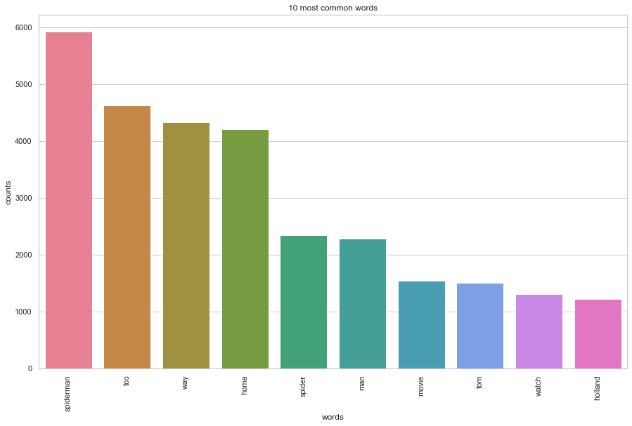

```
--- 10.946373224258423 seconds ---
```

```python
import time
start_time = time.time()

sns.set_style('whitegrid')
%matplotlib inline
# Helper function
def plot_10_most_common_words(count_data, count_vectorizer):
    words = count_vectorizer.get_feature_names()
    total_counts = np.zeros(len(words))
    for t in count_data:
        total_counts+=t.toarray()[0]

    count_dict = (zip(words, total_counts))
    count_dict = sorted(count_dict, key=lambda x:x[1], reverse=True)[0:10]
    words = [w[0] for w in count_dict]
    counts = [w[1] for w in count_dict]
    x_pos = np.arange(len(words))

    plt.figure(2, figsize=(15, 15/1.6180))
    plt.subplot(title='10 most common words')
    sns.set_context("notebook", font_scale=1.25, rc={"lines.linewidth": 2.5})
    sns.barplot(x_pos, counts, palette='husl')
    plt.xticks(x_pos, words, rotation=90)
    plt.xlabel('words')
    plt.ylabel('counts')
    plt.show()
# Initialise the count vectorizer with the English stop words
count_vectorizer = CountVectorizer(stop_words='english')
# Fit and transform the processed tweets
count_data = count_vectorizer.fit_transform(df['TweetTextCleaned'])
# Visualise the 10 most common words
plot_10_most_common_words(count_data, count_vectorizer)

print("--- %s seconds ---" % (time.time() - start_time))
```

### Start of topic analysis, and generation of top 10 topics

```python
import warnings
warnings.simplefilter("ignore", DeprecationWarning)

# Load the LDA model from sk-learn
from sklearn.decomposition import LatentDirichletAllocation as LDA

# Helper function
def print_topics(model, count_vectorizer, n_top_words):
    words = count_vectorizer.get_feature_names()
    for topic_idx, topic in enumerate(model.components_):
        print("\nTopic #%d:" % topic_idx)
        print(" ".join([words[i]
                        for i in topic.argsort()[:-n_top_words - 1:-1]]))

# Tweak the two parameters below
number_topics = 10
number_words = 15
# Create and fit the LDA model
lda = LDA(n_components=number_topics, n_jobs=-1)
lda.fit(count_data)
# Print the topics found by the LDA model
print("Topics found via LDA:")
print_topics(lda, count_vectorizer, number_words)
```

```
Topics found via LDA:

Topic #0:
way home man spider spiderman nwh saw im tco spoilers new 10 got seen movie

Topic #1:
spiderman tco making zendayas dress valentino vqnvp7pfno spoiling venom americans blame jack luke baby marvel

Topic #2:
spiderman movies guy brought plays accessorie day im tco dr nowayhome spidermannowayhome happy peter nwh

Topic #3:
tco tom home way holland spiderman spider man spidermannowayhome think context movie spoilers time favourite

Topic #4:
man spider andrew best tobey garfield maguire tco spidermannowayhome tom spiderman home way holland film

Topic #5:
spiderman tco watch movie way home pulling 6xtujkud3e homies tom holland spider man spidermannowayhome zendaya

Topic #6:
spiderman tco spidermannowayhome watching cinema absolutely parker peter sam post tomorrow performance tom xfirfrgzwz insane

Topic #7:
way home tco man spider spiderman spoiler tom holland umbrella baila review showing scene god

Topic #8:
spoilers avoid home way spider trying man hard spiderman night math harder version came movie

Topic #9:
spiderman tco fan im today spidermannowayhome chenle went boy whos marvel theater el ready ben
```

### Taking the above topics and doing something with them, honestly im not really sure what

I am confused as to what the documents are, where they are coming from. If i knew that i feel like this would make a bit more sense, in that it is determining the most prevelant topic in each document.

```python
topic_list = []

# Create Document — Topic Matrix
lda_output = lda.transform(count_data)

# column names - try to put in actual topic categories with the code below:
#df.columns = ['hashtags','tweet_id','created_at','text','name','user','user_id', 'user_loc', 'user_desc','user_followers',
#              'user_friends','user_listed', 'user_created', 'user_favs','user_verified', 'user_statuses']
df.columns = ['hashtags','tweet_id','created_at','text','name','user','user_id', 'user_loc', 'user_desc','user_followers','user_friends','user_listed', 'user_created', 'user_favs','user_verified', 'user_statuses','TweetTextCleaned']
topicnames = ["Topic" + str(i) for i in range(lda.n_components)]

# index names
docnames = ["Doc" + str(i) for i in range(len(df['TweetTextCleaned']))]

# Make the pandas dataframe
df_document_topic = pd.DataFrame(np.round(lda_output, 2), columns=topicnames, index=docnames)

# Get dominant topic for each document
dominant_topic = np.argmax(df_document_topic.values, axis=1)
df_document_topic['dominant_topic'] = dominant_topic
topic_list.append(dominant_topic)

# Styling
def color_green(val):
 color = 'green' if val > .1 else 'black'
 return 'color: {col}'.format(col=color)
def make_bold(val):
 weight = 700 if val > .1 else 400
 return 'font-weight: {weight}'.format(weight=weight)

# Apply Style
df_document_topics = df_document_topic.head(15).style.applymap(color_green).applymap(make_bold)
df_document_topics
```

|  | Topic0 | Topic1 | Topic2 | Topic3 | Topic4 | Topic5 | Topic6 | Topic7 | Topic8 | Topic9 | dominant_topic |
| --- | --- | --- | --- | --- | --- | --- | --- | --- | --- | --- | --- |
| Doc0 | 0.050000 | 0.050000 | 0.050000 | 0.050000 | 0.050000 | 0.050000 | 0.050000 | 0.050000 | 0.050000 | 0.550000 | 9 |
| Doc1 | 0.050000 | 0.050000 | 0.050000 | 0.050000 | 0.050000 | 0.050000 | 0.050000 | 0.050000 | 0.050000 | 0.550000 | 9 |
| Doc2 | 0.030000 | 0.030000 | 0.030000 | 0.030000 | 0.030000 | 0.700000 | 0.030000 | 0.030000 | 0.030000 | 0.030000 | 5 |
| Doc3 | 0.010000 | 0.010000 | 0.010000 | 0.010000 | 0.460000 | 0.290000 | 0.010000 | 0.010000 | 0.200000 | 0.010000 | 4 |
| Doc4 | 0.010000 | 0.010000 | 0.010000 | 0.010000 | 0.010000 | 0.010000 | 0.010000 | 0.010000 | 0.010000 | 0.870000 | 9 |
| Doc5 | 0.030000 | 0.330000 | 0.030000 | 0.030000 | 0.030000 | 0.030000 | 0.030000 | 0.410000 | 0.030000 | 0.030000 | 7 |
| Doc6 | 0.010000 | 0.010000 | 0.010000 | 0.010000 | 0.010000 | 0.010000 | 0.010000 | 0.010000 | 0.010000 | 0.890000 | 9 |
| Doc7 | 0.010000 | 0.010000 | 0.010000 | 0.010000 | 0.830000 | 0.010000 | 0.010000 | 0.110000 | 0.010000 | 0.010000 | 4 |
| Doc8 | 0.010000 | 0.010000 | 0.010000 | 0.010000 | 0.010000 | 0.930000 | 0.010000 | 0.010000 | 0.010000 | 0.010000 | 5 |
| Doc9 | 0.700000 | 0.030000 | 0.030000 | 0.030000 | 0.030000 | 0.030000 | 0.030000 | 0.030000 | 0.030000 | 0.030000 | 0 |
| Doc10 | 0.010000 | 0.010000 | 0.010000 | 0.010000 | 0.920000 | 0.010000 | 0.010000 | 0.010000 | 0.010000 | 0.010000 | 4 |
| Doc11 | 0.010000 | 0.010000 | 0.010000 | 0.510000 | 0.230000 | 0.010000 | 0.210000 | 0.010000 | 0.010000 | 0.010000 | 3 |
| Doc12 | 0.010000 | 0.010000 | 0.010000 | 0.010000 | 0.910000 | 0.010000 | 0.010000 | 0.010000 | 0.010000 | 0.010000 | 4 |
| Doc13 | 0.010000 | 0.010000 | 0.010000 | 0.010000 | 0.690000 | 0.010000 | 0.010000 | 0.010000 | 0.210000 | 0.010000 | 4 |
| Doc14 | 0.010000 | 0.010000 | 0.010000 | 0.010000 | 0.010000 | 0.010000 | 0.010000 | 0.010000 | 0.010000 | 0.870000 | 9 |

```python
df['Topic'] = dominant_topic

df['Topic'].head()
```

```
0    9
1    9
2    5
3    4
4    9
Name: Topic, dtype: int32
```

```python
print(df.isnull().values.any())
```

```
True
```

```python
df.head()
```

[output not shown]

### Analysis of topics using pyLDAvis

This took me a while to figure out, because it kept running but nothing was happpening, I kept looking up documentation of pyLDAvis and it seemed to be alright, just not producing the topic analysis graph, i was expecting. It took me about an hour to figure out that the .html at the bottom of the block was usable.

```python
import pyLDAvis
```

```python
#%%time
from pyLDAvis import sklearn as sklearn_lda
import pickle
import pyLDAvis
#LDAvis_data_filepath = os.path.join('D:/Politics2020/Cleaned/ldavis_prepared_'+str(number_topics))
LDAvis_data_filepath = os.path.join('C:/Users/student/Documents/Junior/Fall/Programming/Twitter Project/ListenerPylDavis.csv')

# # this is a bit time consuming - make the if statement True
# # if you want to execute visualization prep yourself
if 1 == 1:
    LDAvis_prepared = sklearn_lda.prepare(lda, count_data, count_vectorizer)
    with open(LDAvis_data_filepath, 'wb') as f:
        pickle.dump(LDAvis_prepared, f)


# load the pre-prepared pyLDAvis data from disk
with open(LDAvis_data_filepath, 'rb') as f:
    LDAvis_prepared = pickle.load(f)

#pyLDAvis.save_html(LDAvis_prepared, 'D:/Politics2020/Cleaned/ldavis_prepared_'+ str(number_topics) +'.html')
pyLDAvis.save_html(LDAvis_prepared, 'C:/Users/student/Documents/Junior/Fall/Programming/Twitter Project/data.html')
```